# Analyses exploratoires

Laudine Carbuccia

2023-07-21

## Part I: Brief description of the sample

This first part is dedicated to a description of the sample.

### Total sample

1861 surveys have been completed overall.

### Participants with at least one phone number

Over the 1861 participants,

- 39.33 % are Low-SES (i.e., no tertiary education) (N=732).
- 60 % have never used ECS (N=1112)
- Single mothers: 10 % (N =160). Mothers were recruited between their fourth and ninth months of pregnancy.
- Primparae: 40 % (N =790)
- Digital divide: More than a third (32%) of low-SES respondents don’t have access to a computer compared to 4.7% for High-SES respondents. Similarly, one third (28.8%) of mothers born abroad don’t have access to a computer compared to 3.7% for non-migrants.

## Main variables

### Age

The age of the participants follow a normal distribution:

```
## # A tibble: 1 × 2
##    mean median
##   <dbl>  <dbl>
## 1  32.3     32
```

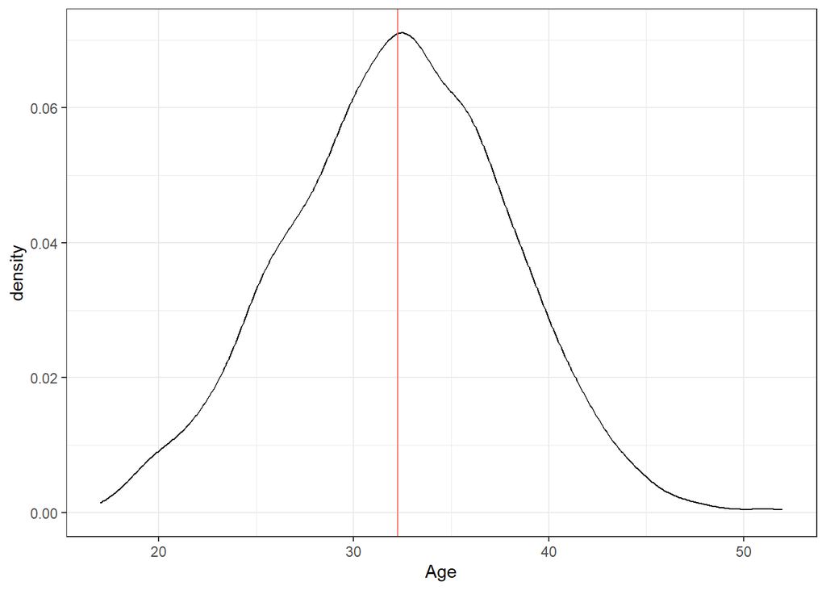

## Level of education of the mothers

39.33 % of Low-SES (i.e., no tertiary education) (N=732).

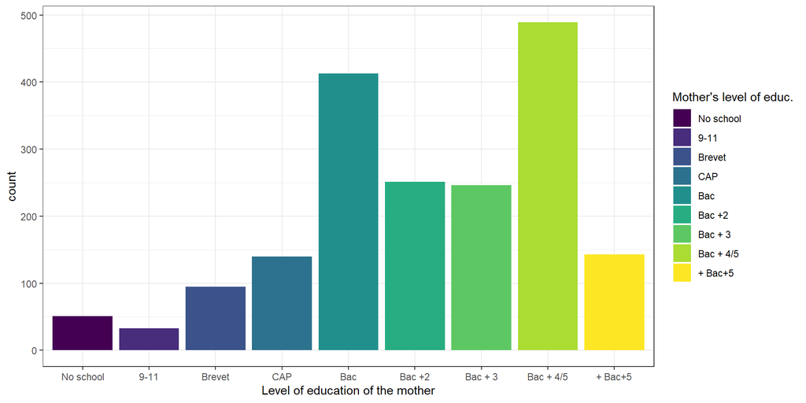

## Income range of the mothers

A significant amount of mothers included in the sample earn less than 500€ per month: it is the case for 21.33 % of them. 1.61 % of the total sample earn less than 500€ per month and are single mothers.

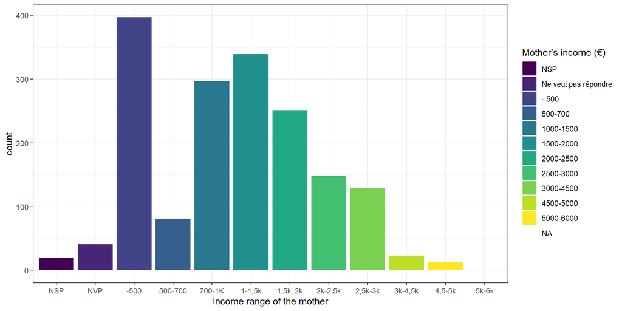

## Income range of the family

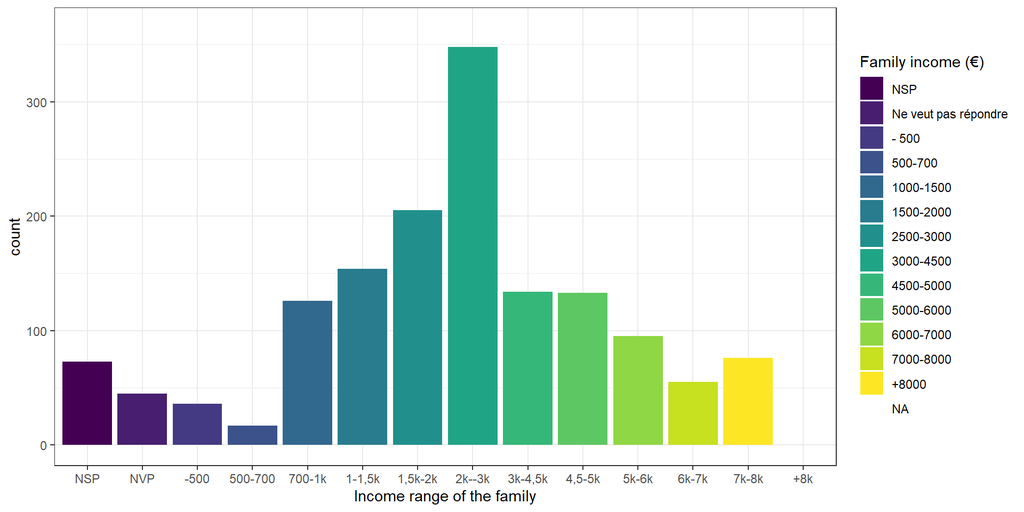

## Occupation status of the mother

A majority (70%) of mothers are employed at the date of the interview.

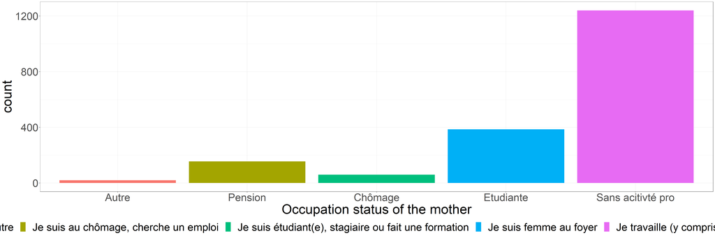

## Migration status

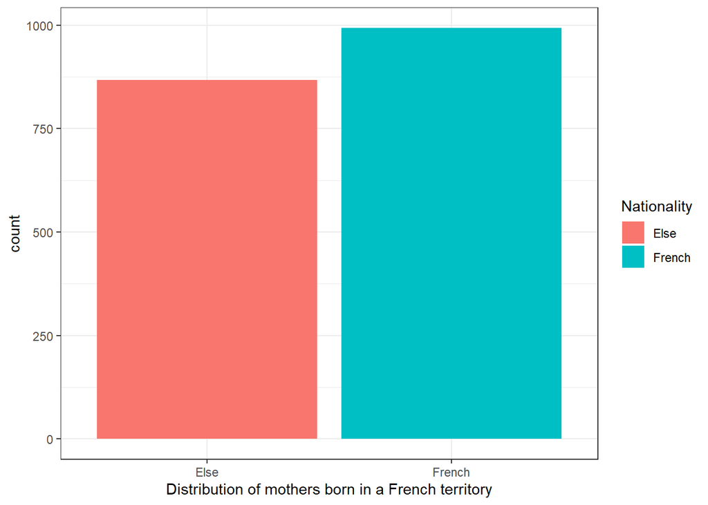

47% of mothers are born abroad (‘Else’ in the figure).This may seem unrealistic, but it is actually quite close from the population data of Seine Saint Denis (93), Val de Marne (94) and Paris (75).

### Place of birth of migrants mothers

Most of the mothers born abroad come from Sub-Saharan Africa and MENA. The distribution of the birthplaces of participants is as follows:

| BirthPlace | n |
| --- | --- |
| En France métropolitaine | 953 |
| Afrique subsaharienne | 389 |
| MENA (Maghreb +Arabie saoudite, etc.) | 298 |
| Europe/Amérique du Nord, Australie | 87 |
| Asie (hors MENA) | 65 |
| Dans un territoire français d’outre-mer | 40 |
| Amérique Latine (à partir du Mexique) | 25 |
| Autre | 2 |
| Je ne souhaite pas répondre | 2 |

| DateArrival | n |
| --- | --- |
| Moins de 5 ans | 296 |
| Entre 5 et 10 ans | 261 |
| Entre 10 et 20 ans | 187 |
| Il y a plus de 20 ans | 121 |
|  | 2 |
| Je ne sais pas | 1 |

## Geographical distribution of the participants

| Dep | n |
| --- | --- |
| 94 | 711 |
| 75 | 698 |
| 93 | 452 |

We have more people from 94 and 75 than from Seine Saint Denis. This is probably due to our recruitment strategy. One family that had two living places including 91 was included in the survey by one research assistant. We included it in these analyses but the household was excluded from the RCT.

# Part II: Childcare related outcomes

## Childcare plans after birth

Parents wanting to use an ECS are over-represented in the sample: 80 % want to use them.

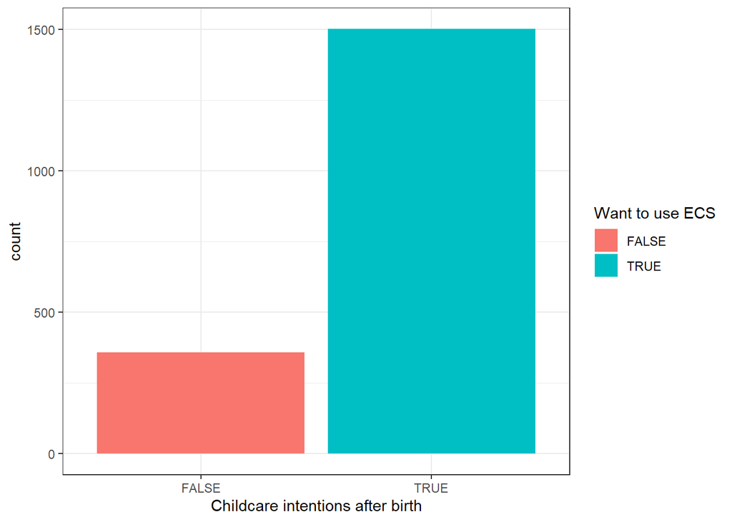

### Analysis for low-SES

Among low-SES parents, parents wanting to use an ECS are still over-represented in the sample: 70 % want to use them compared to 90 % for the high-SES parents The same holds for migrant families: 80 % want to use them. Even more interestingly, even among inactive parents, parents wanting to use an ECS are still over-represented in the sample: 70 % want to use them.

## Timing of ECS wanted

```
##
##  Pearson's Chi-squared test with Yates' continuity correction
##
## data:  data_full$Educ and data_full$ECSDateBinary
## X-squared = 15.671, df = 1, p-value = 7.536e-05
```

Among parents wanting to use an ECS, those wanting *crèches* (daycare centers) are over-represented: 80 % want to use them (60 % on the general population).

[figure not shown]

### Analysis for low-SES

Again, the pattern is quite similar if we restrict the analyses to low-SES mothers: 80 % want to use daycare. The same holds for migrant families: 80 % want to use them. Even more interestingly, even among inactive parents, the proportion wanting to use daycare is still quite high and the pattern is the same: 80 %. Only the drop-in daycare (halte-garderies) has a slightly higher proportion compared to the general population, but the increase is very modest: 1.954 percentage points.

[figure not shown]

This raises the question of the types of ECS than are known by mothers. Maybe crèches is the only structure they know of.

# Information dynamics

## Number of ECS known

Number of ECS Known (KnownNbTypeECS)

|  | Number of ECS Known |
| --- | --- |
| (Intercept) | 1.716*** [1.612, 1.819] |
|  | 0.053 (<0.001) |
| EducSup | 0.902*** [0.770, 1.035] |
|  | 0.068 (<0.001) |
| R2 | 0.087 |
| R2 Adj. | 0.087 |
| Num.Obs. | 1861 |

Coefficient, 95 % CI in bracklets, standard errors, p-value or adjusted p-value in parenthesis

First, low-SES mothers knew on average significantly less ECS types than their more affluent counterparts. When asked to tell us all the ECS type they knew, mothers knew 2.26 ECS types on average. But while high-SES mothers knew on average 2.6182462 ECS types, low-SES mothers knew on average 1.715847 of them (t = -13.2, p-value < 2.2e-16).